# Spatial Analysis

PPOL 6805 / DSAN 6750: GIS for Spatial Data Science

Author

Sangeun Lee

# Overview

Electricity is a unique commodity in microeconomic theory. Unlike standard goods, its delivery is constrained by the strict physical laws of the transmission grid. In an ideal “copperplate” world, electricity would flow freely without resistance, allowing for a single market-clearing price where supply equals demand. However, in the real world, transmission lines have finite capacity. When these lines become congested, the grid cannot physically transport power from the supply side to the demand side.

The rise of renewable energy sources, combined with the explosive growth of energy-intensive Data Centers (DCs), has placed unprecedented strain on grid capacity. Yet, despite facing the same physical problem of the transmission grid, Germany and the United States have adopted opposite pricing mechanisms to solve the problem of how electricity prices reflect the real costs of serving new loads.

Germany operates as a **single-price market**, treating the entire country (along with Luxembourg) as a single bidding zone. All market participants face a single uniform sales price, even though generation resources and transmission constraints differ sharply between the wind-rich North and the industrial South. To maintain physical stability, German grid operators must carry out expensive balancing measures, such as redispatch and curtailing renewables. These costs are treated as an externality and socialized across all consumers via grid fees. Even within this framework, final retail prices still vary by region because grid and tax charges differ by region.

By contrast, the majority of deregulated markets in the United States use **locational marginal pricing (LMP)**. This model integrates the physical constraints of the grid directly into the market ex-ante, calculating prices at thousands of nodes on the grid, and each node’s price reflects local energy costs, transmission congestion, and losses. Retail electricity prices add transmission, distribution, and other components on top of these locational wholesale prices.

# Understanding of the two Models

The core economic problem in electricity markets is the efficient allocation of generation and network capacity when supply costs and transmission constraints differ by location. To illustrate the difference between models, consider a highly simplified two-region model consisting of Region A (abundant low-cost generation plants), and Region B (high demand with expensive local generation), where $MC^A < MC^B$ and the two regions are connected by a transmission line with finite capacity of T ̅ . If there were no transmission constraints, the least cost dispatch would serve both regions at a common marginal cost, equalized between A and B. With a binding transmission constraint, however, the marginal cost of serving an additional unit of demand in B is higher than in A.

# The U.S. Electricity Market

The U.S. market computes LMPs by incorporating both energy and congestion components, allowing nodes behind a constraint to see higher prices when transmission is scarce. When a new large load, such as a DCs, connects in a region already close to its transmission or generation capacity, the marginal cost of serving an additional megawatt at that node rises and is reflected in an elevated local price. The cost of congestion is borne primarily by consumers at constrained locations, either directly through wholesale prices or indirectly through retail tariffs that reflect the higher cost of supply in that area. This can lead to substantial spatial variation in average retail prices across U.S. states and utility territories, and recent analyses indicated that regions with intense DCs development are seeing especially rapid wholesale price growth and higher capacity costs. While this results in substantial spatial variation in prices, it ensures the large developers to face the marginal cost of their siting decision.

```r
library(tidyverse) |> suppressPackageStartupMessages()
library(sf) |> suppressPackageStartupMessages()
library(spdep) |> suppressPackageStartupMessages()
library(sfdep) |> suppressPackageStartupMessages()
library(spatialreg) |> suppressPackageStartupMessages()
library(broom) |> suppressPackageStartupMessages()
library(mapview) |> suppressPackageStartupMessages()
install.packages(c("spatstat", "rnaturalearth", "tidygeocoder", "cowplot"))
library(spatstat) |> suppressPackageStartupMessages()
library(rnaturalearth) |> suppressPackageStartupMessages()
library(tidygeocoder) |> suppressPackageStartupMessages()
library(cowplot) |> suppressPackageStartupMessages()
library(viridis) |> suppressPackageStartupMessages()
```

```r
us_elecprices <- read_csv("https://raw.githubusercontent.com/SangeunL/GIS-Final-Project/refs/heads/main/electricity_2024.csv")
pop_data <- read_csv("https://raw.githubusercontent.com/SangeunL/GIS-Final-Project/refs/heads/main/USpop24.csv")
us_states <- ne_states(country = "united states of america", returnclass = "sf") %>%
  filter(!name %in% c("Alaska", "Hawaii")) %>%
  select(name, postal, geometry)

pop_data <- pop_data %>%
  mutate(Statepop = gsub("^\\.", "", State)) %>%
  select(State = Statepop, population = Pop)

elec_pop_map <- us_states %>%
  left_join(pop_data, by = c("name" = "State")) %>%
  left_join(us_elecprices, by = c("name" = "State"))
```

## 1. Statistical Analysis: Does Population Drive Price?

To test the hypothesis that population density exerts upward pressure on electricity prices, I first employed a standard Ordinary Least Squares (OLS) regression. The model predicts residential electricity price (Price_Res) based on the natural log of population (log(population)), assuming that errors are independent and identically distributed (i.i.d.).

```r
ols_fit <- lm(Price_Res ~ log(population), data=elec_pop_map)
result_df <- broom::tidy(ols_fit)
result_df
```

| term | estimate | std.error | statistic | p.value |
| --- | --- | --- | --- | --- |
| (Intercept) | 11.631617 | 11.4984661 | 1.0115799 | 0.3169185 |
| log(population) | 0.349824 | 0.7517183 | 0.4653658 | 0.6438187 |

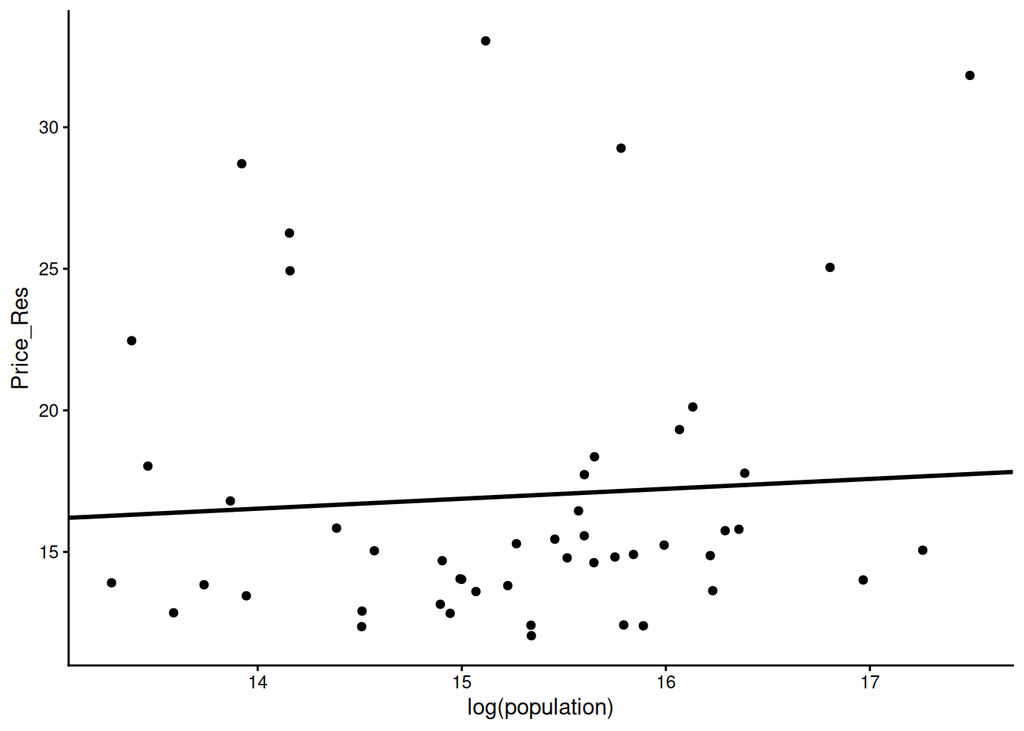

```r
estimates <- result_df$estimate
b0_hat <- estimates[1]
b1_hat <- estimates[2]
elec_pop_map |> ggplot(aes(x=log(population), y=Price_Res)) +
  geom_point() +
  geom_abline(
    slope = b1_hat, intercept=b0_hat,
    linewidth=1
  ) +
  theme_classic()
```

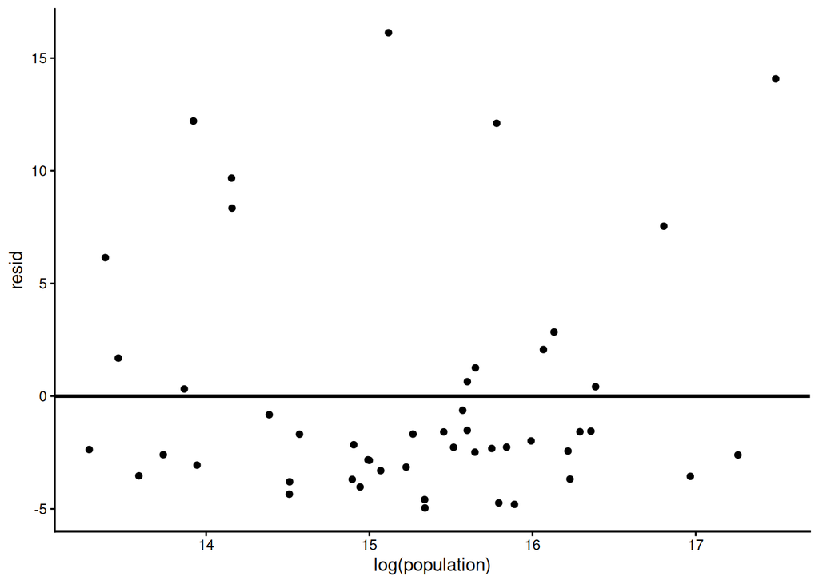

```r
# Residual plot
elec_pop_map$resid <- ols_fit$residuals
elec_pop_map |> ggplot(aes(x=log(population), y=resid)) +
  geom_point() +
  geom_hline(yintercept=0, linewidth=1) +
  theme_classic()
```

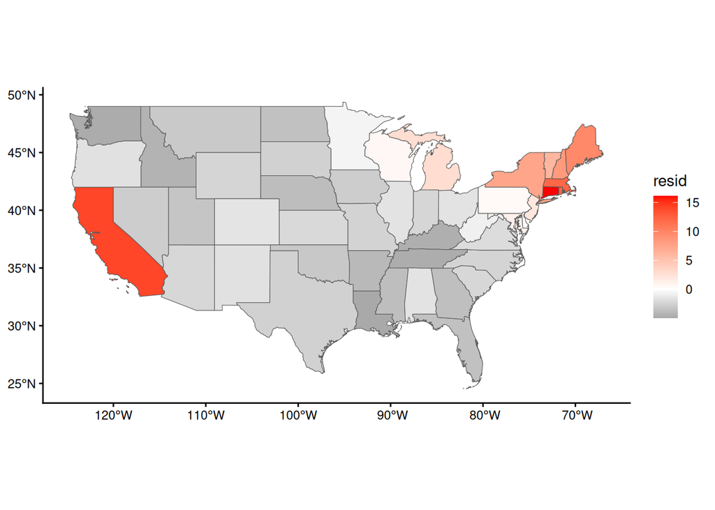

```r
#Residual map
elec_pop_map |> ggplot(aes(fill = resid)) +
    geom_sf() +
    scale_fill_gradient2(low = "black", mid = "white", high = "red", midpoint = 0) +
    theme_classic()
```

There is a visual evidence that **our error terms are not independent of the spatial distribution of states!**

The OLS results initially suggest a weak or insignificant relationship between population and price ($p > 0.05$). However, the diagnostic plots reveal a critical flaw in the model. The Residual Map above does not show random **“noise”**. Instead, it displays clear regional clustering: large swathes of the country are either uniformly positive (red) or uniformly negative (black). This pattern, which is especially evident in the New England region, suggests that an unobserved variable—likely the regional transmission grid—is causing the errors in one state to be correlated with the errors in neighboring states. This violates the independence assumption of OLS. To confirm this mathematically, we calculate the global Moran’s I statistic.

```r
us_nb <- st_contiguity(elec_pop_map)
moran_residuals <- global_moran_test(elec_pop_map$resid, us_nb , st_weights(us_nb))
moran_residuals
```

```
    Moran I test under randomisation

data:  x
weights: listw

Moran I statistic standard deviate = 7.6607, p-value = 9.249e-15
alternative hypothesis: greater
sample estimates:
Moran I statistic       Expectation          Variance
      0.709202866      -0.020833333       0.009081484
```

The Global Moran’s I test returns a statistic of **0.7092** with a highly significant p-value. A score this close to 1 indicates extremely strong positive spatial autocorrelation.

This confirms that state residential electricity prices are not independent; they are physically linked to their neighbors. A high price in one state “spills over” to adjacent states due to shared grid infrastructure and cross-border electricity trading. Therefore, we must reject the OLS model and adopt a Spatial Lag Model (SAR), which explicitly accounts for this “neighborhood effect” (Rho).

```r
ldv_fit <- lagsarlm(Price_Res ~ log(population), data=elec_pop_map, listw=nb2listw(us_nb))
broom::tidy(ldv_fit)
```

| term | estimate | std.error | statistic | p.value |
| --- | --- | --- | --- | --- |
| rho | 0.8146577 | 0.0723649 | 11.257642 | 0.0000000 |
| (Intercept) | -11.9715878 | 6.3111265 | -1.896902 | 0.0578409 |
| log(population) | 0.9989780 | 0.4157425 | 2.402877 | 0.0162667 |

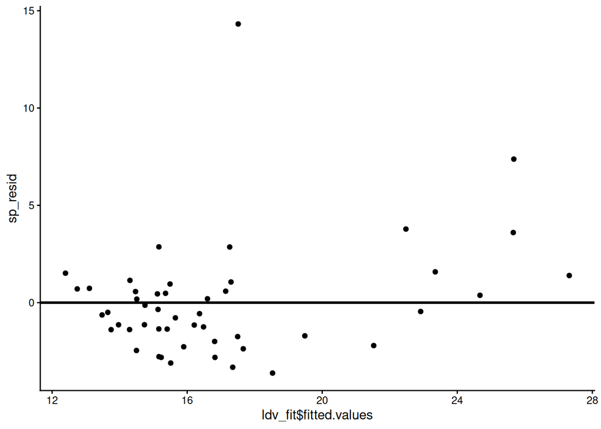

```r
elec_pop_map$sp_resid <- ldv_fit$resid
elec_pop_map |> ggplot(aes(x=ldv_fit$fitted.values, y=sp_resid)) +
  geom_point() +
  geom_hline(yintercept=0, linewidth=1) +
  theme_classic()
```

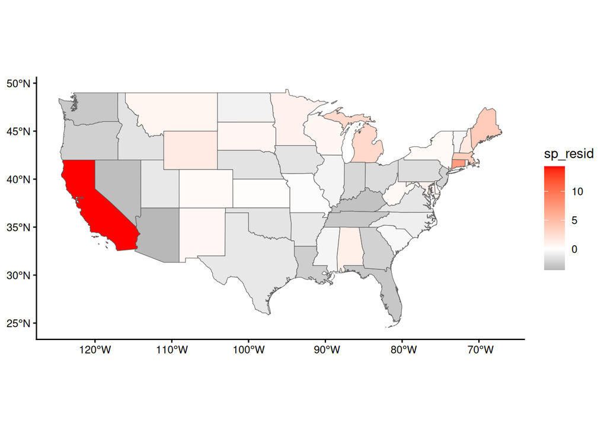

```r
elec_pop_map |> ggplot(aes(fill = sp_resid)) +
    geom_sf() +
    scale_fill_gradient2(low ="Black", mid = "White", high = "Red", midpoint = 0) +
    theme_classic()
```

By incorporating the spatial lag term (Rho), the model’s performance improves significantly. Two key findings emerge:

1. **Rho (0.815)** is highly significant, confirming that a state’s price is strongly predicted by its neighbors’ prices.
2. Population (log(population)) becomes statistically significant **($p < 0.05$)** with a positive coefficient.

This reveals a relationship that the OLS model missed: **once we control for regional grid effects, higher population density does significantly drive up electricity prices.** We can perform a final quality check on the new residuals (sp_resid) to ensure the spatial bias has been removed.

```r
moran_spresiduals <- global_moran_test(elec_pop_map$sp_resid, us_nb, st_weights(us_nb))
moran_spresiduals
```

```
    Moran I test under randomisation

data:  x
weights: listw

Moran I statistic standard deviate = 0.26642, p-value = 0.395
alternative hypothesis: greater
sample estimates:
Moran I statistic       Expectation          Variance
      0.001992140      -0.020833333       0.007340243
```

The final Moran’s I test on the spatial residuals is insignificant **(0.0019)**, and the p-value is **$> 0.05$**. This indicates that the Spatial Lag model has successfully filtered out the spatial autocorrelation. The remaining errors are random, validating the statistical conclusion that population density strains the grid and raises prices.

## 2. Physical Analysis: The Supply-Demand Mismatch

Having established the economic link between population and price, we can now investigate the physical mechanism behind it. The strong spatial dependence found above (Rho) exists because “Deficit States” must physically import electrons from “Surplus States.”

We calculate the Grid Independence Ratio for each state using the formula: $\text{Independence} = \left( \frac{\text{Net Generation (MWh)}}{\text{Total Retail Sales (MWh)}} \right) \times 100$

Value >= 100% (Surplus): The state is an “Exporter” (a Power Plant for its neighbors).

```r
us_elec_2024 <- read.csv("https://raw.githubusercontent.com/SangeunL/GIS-Final-Project/refs/heads/main/2024_State_Elec.csv")

us_total_2024 <- elec_pop_map %>%
  left_join(us_elec_2024, by = c("name" = "State"))

us_total_2024 <- us_total_2024 %>%
  mutate(
    pct_green = (net_renew_gen / net_gen) * 100,
    independence = (net_gen / tot_ret_sales) * 100
    )
```

**What these calculations represent:**

**- independence:** Shows whether a state is self-sufficient (>100%) or dependent on imports (<100%). States with high population density and limited local generation will have low independence scores.

**- pct_green:** The percentage of generation from renewable sources (wind, solar, hydroelectric). This varies dramatically by region due to resource endowments and policy choices.

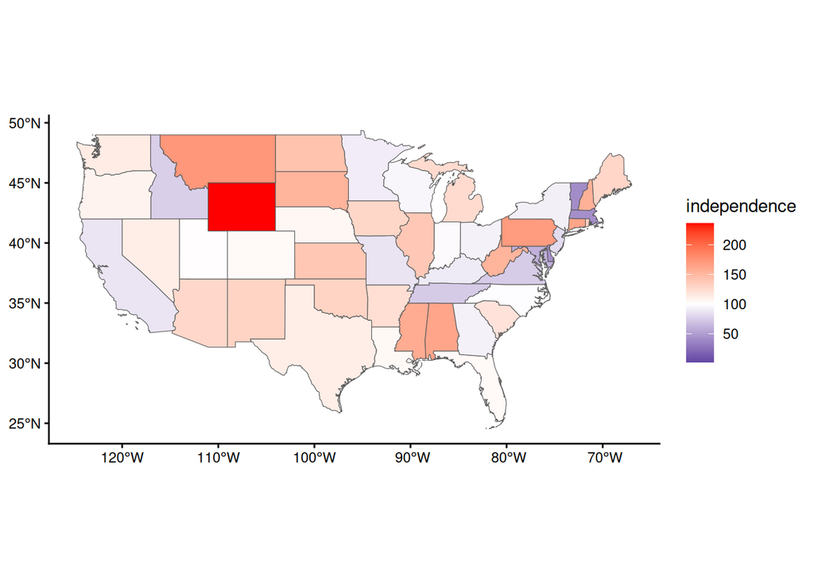

```r
us_total_2024 |> ggplot(aes(fill = independence)) +
    geom_sf() +
    scale_fill_gradient2(low = "navy", mid = "white", high = "red", midpoint = 100) +
    theme_classic()
```

This spatial mismatch is the fundamental driver of transmission congestion and spatial price variation.

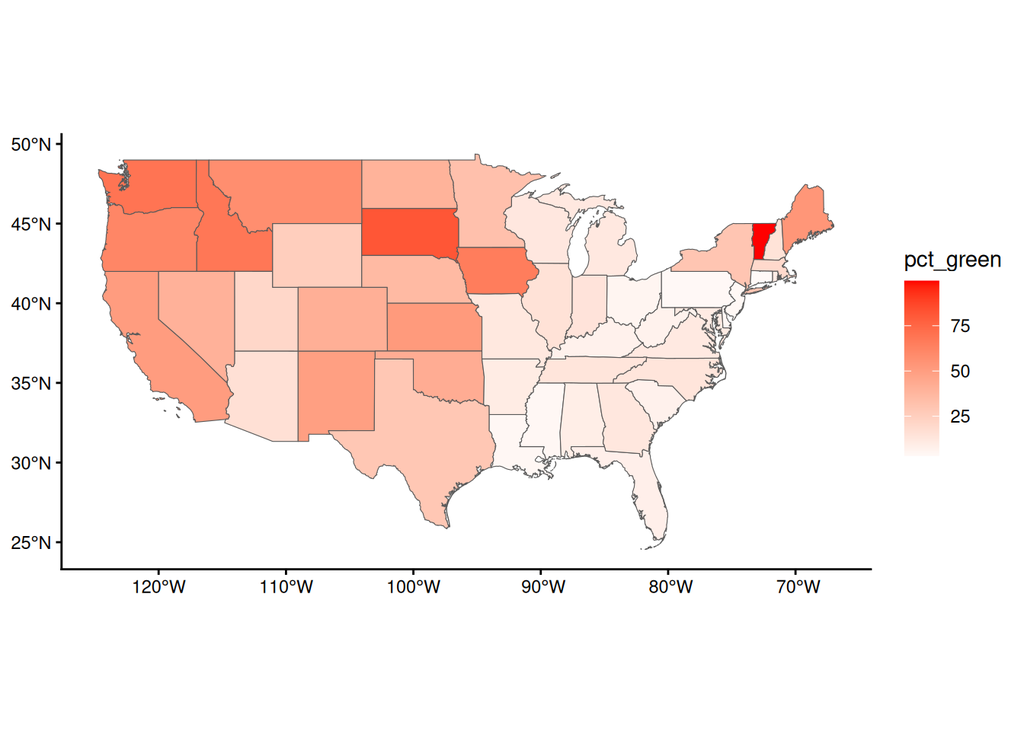

```r
us_total_2024 |> ggplot(aes(fill = pct_green)) +
    geom_sf() +
    scale_fill_gradient2(low = "white", high = "red", ) +
    theme_classic()
```

Renewable generation is also highly concentrated by geography.

Texas, Iowa, and the northern Great Plains dominate wind generation. California, Arizona, and parts of the Southwest lead in solar.

## 3. Linking Price, Independence, and Renewable Share

Now we can extend the spatial model to test whether independence and renewable generation help explain spatial variation in electricity prices, beyond just population and geographic proximity.

```r
ldv_extended <- lagsarlm(avg_ret_price ~ log(population) + independence + pct_green, data = us_total_2024, listw = nb2listw(us_nb))

summary(ldv_extended)
```

```
Call:lagsarlm(formula = avg_ret_price ~ log(population) + independence +
    pct_green, data = us_total_2024, listw = nb2listw(us_nb))

Residuals:
     Min       1Q   Median       3Q      Max
-3.67209 -1.73140 -0.65037  1.00259 12.45010

Type: lag
Coefficients: (asymptotic standard errors)
                  Estimate Std. Error z value Pr(>|z|)
(Intercept)     -9.5751896  6.6571247 -1.4383  0.15034
log(population)  0.8627628  0.3997514  2.1582  0.03091
independence    -0.0105008  0.0094207 -1.1147  0.26500
pct_green        0.0104247  0.0169289  0.6158  0.53803

Rho: 0.8036, LR test value: 42.475, p-value: 7.1598e-11
Asymptotic standard error: 0.076379
    z-value: 10.521, p-value: < 2.22e-16
Wald statistic: 110.7, p-value: < 2.22e-16

Log likelihood: -121.3696 for lag model
ML residual variance (sigma squared): 6.6145, (sigma: 2.5719)
Number of observations: 49
Number of parameters estimated: 6
AIC: 254.74, (AIC for lm: 295.21)
LM test for residual autocorrelation
test value: 0.0015353, p-value: 0.96874
```